# HW4

Tanisha Pardasani

## Importing Packages

```r
library(ggplot2)
library(tidyverse)
```

## Reading Data

```r
# Reading in and cleaning the data
airbnb <- read.csv('AB_NYC_2019.csv', stringsAsFactors = TRUE)
airbnb$id <- NULL
airbnb$reviews_per_month <- ifelse(is.na(airbnb$reviews_per_month) == TRUE, 0,
                                   airbnb$reviews_per_month)

head(airbnb)
```

```
##                                               name host_id   host_name
## 1               Clean & quiet apt home by the park    2787        John
## 2                            Skylit Midtown Castle    2845    Jennifer
## 3              THE VILLAGE OF HARLEM....NEW YORK !    4632   Elisabeth
## 4                  Cozy Entire Floor of Brownstone    4869 LisaRoxanne
## 5 Entire Apt: Spacious Studio/Loft by central park    7192       Laura
## 6        Large Cozy 1 BR Apartment In Midtown East    7322       Chris
##   neighbourhood_group neighbourhood latitude longitude       room_type price
## 1            Brooklyn    Kensington 40.64749 -73.97237    Private room   149
## 2           Manhattan       Midtown 40.75362 -73.98377 Entire home/apt   225
## 3           Manhattan        Harlem 40.80902 -73.94190    Private room   150
## 4            Brooklyn  Clinton Hill 40.68514 -73.95976 Entire home/apt    89
## 5           Manhattan   East Harlem 40.79851 -73.94399 Entire home/apt    80
## 6           Manhattan   Murray Hill 40.74767 -73.97500 Entire home/apt   200
##   minimum_nights number_of_reviews last_review reviews_per_month
## 1              1                 9  2018-10-19              0.21
## 2              1                45  2019-05-21              0.38
## 3              3                 0                          0.00
## 4              1               270  2019-07-05              4.64
## 5             10                 9  2018-11-19              0.10
## 6              3                74  2019-06-22              0.59
##   calculated_host_listings_count availability_365
## 1                              6              365
## 2                              2              355
## 3                              1              365
## 4                              1              194
## 5                              1                0
## 6                              1              129
```

```r
# Structure of the data
str(airbnb)
```

```
## 'data.frame':    48895 obs. of  15 variables:
##  $ name                          : Factor w/ 47906 levels ""," 1 Bed Apt in Utopic Williamsburg ",..: 12573 38016 45018 15591 19219 24849 8257 24896 15486 17573 ...
##  $ host_id                       : int  2787 2845 4632 4869 7192 7322 7356 8967 7490 7549 ...
##  $ host_name                     : Factor w/ 11453 levels ""," Valéria",..: 4997 4791 2913 6210 5929 1938 3549 9649 6880 1235 ...
##  $ neighbourhood_group           : Factor w/ 5 levels "Bronx","Brooklyn",..: 2 3 3 2 3 3 2 3 3 3 ...
##  $ neighbourhood                 : Factor w/ 221 levels "Allerton","Arden Heights",..: 109 128 95 42 62 138 14 96 203 36 ...
##  $ latitude                      : num  40.6 40.8 40.8 40.7 40.8 ...
##  $ longitude                     : num  -74 -74 -73.9 -74 -73.9 ...
##  $ room_type                     : Factor w/ 3 levels "Entire home/apt",..: 2 1 2 1 1 1 2 2 2 1 ...
##  $ price                         : int  149 225 150 89 80 200 60 79 79 150 ...
##  $ minimum_nights                : int  1 1 3 1 10 3 45 2 2 1 ...
##  $ number_of_reviews             : int  9 45 0 270 9 74 49 430 118 160 ...
##  $ last_review                   : Factor w/ 1765 levels "","2011-03-28",..: 1503 1717 1 1762 1534 1749 1124 1751 1048 1736 ...
##  $ reviews_per_month             : num  0.21 0.38 0 4.64 0.1 0.59 0.4 3.47 0.99 1.33 ...
##  $ calculated_host_listings_count: int  6 2 1 1 1 1 1 1 1 4 ...
##  $ availability_365              : int  365 355 365 194 0 129 0 220 0 188 ...
```

```r
# Summary of the data
summary(airbnb)
```

```
##                                name          host_id
##  Hillside Hotel                  :   18   Min.   :     2438
##  Home away from home             :   17   1st Qu.:  7822033
##                                  :   16   Median : 30793816
##  New york Multi-unit building    :   16   Mean   : 67620011
##  Brooklyn Apartment              :   12   3rd Qu.:107434423
##  Loft Suite @ The Box House Hotel:   11   Max.   :274321313
##  (Other)                         :48805
##         host_name        neighbourhood_group            neighbourhood
##  Michael     :  417   Bronx        : 1091    Williamsburg      : 3920
##  David       :  403   Brooklyn     :20104    Bedford-Stuyvesant: 3714
##  Sonder (NYC):  327   Manhattan    :21661    Harlem            : 2658
##  John        :  294   Queens       : 5666    Bushwick          : 2465
##  Alex        :  279   Staten Island:  373    Upper West Side   : 1971
##  Blueground  :  232                          Hell's Kitchen    : 1958
##  (Other)     :46943                          (Other)           :32209
##     latitude       longitude                room_type         price
##  Min.   :40.50   Min.   :-74.24   Entire home/apt:25409   Min.   :    0.0
##  1st Qu.:40.69   1st Qu.:-73.98   Private room   :22326   1st Qu.:   69.0
##  Median :40.72   Median :-73.96   Shared room    : 1160   Median :  106.0
##  Mean   :40.73   Mean   :-73.95                           Mean   :  152.7
##  3rd Qu.:40.76   3rd Qu.:-73.94                           3rd Qu.:  175.0
##  Max.   :40.91   Max.   :-73.71                           Max.   :10000.0
##
##  minimum_nights    number_of_reviews     last_review    reviews_per_month
##  Min.   :   1.00   Min.   :  0.00              :10052   Min.   : 0.000
##  1st Qu.:   1.00   1st Qu.:  1.00    2019-06-23: 1413   1st Qu.: 0.040
##  Median :   3.00   Median :  5.00    2019-07-01: 1359   Median : 0.370
##  Mean   :   7.03   Mean   : 23.27    2019-06-30: 1341   Mean   : 1.091
##  3rd Qu.:   5.00   3rd Qu.: 24.00    2019-06-24:  875   3rd Qu.: 1.580
##  Max.   :1250.00   Max.   :629.00    2019-07-07:  718   Max.   :58.500
##                                      (Other)   :33137
##  calculated_host_listings_count availability_365
##  Min.   :  1.000                Min.   :  0.0
##  1st Qu.:  1.000                1st Qu.:  0.0
##  Median :  1.000                Median : 45.0
##  Mean   :  7.144                Mean   :112.8
##  3rd Qu.:  2.000                3rd Qu.:227.0
##  Max.   :327.000                Max.   :365.0
##
```

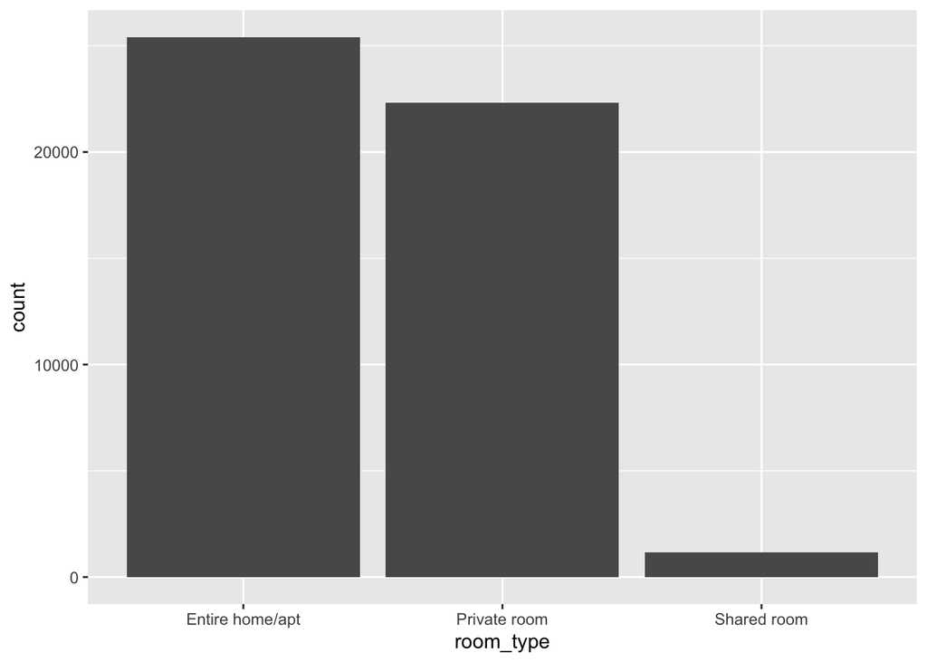

```r
# Barplot of types of airbnbs
home_split <- ggplot(airbnb, aes(x=room_type)) + geom_bar()
home_split
```

```r
# Average price by room type
price_per_airbnb_type <- round(tapply(airbnb$price,
                                      airbnb$room_type, mean, na.rm=TRUE), 2)
price_per_airbnb_type
```

```
## Entire home/apt    Private room     Shared room
##          211.79           89.78           70.13
```

Entire home/apt room types are the most expensive, with an average price of $211.79 while shared rooms tend to be the least expensive, with an average price of $70.13.

```r
# Average number of reviews by room type
reviews_per_airbnb_type <- tapply(airbnb$reviews_per_month,
                                   airbnb$room_type, mean, na.rm=TRUE)
reviews_per_airbnb_type
```

```
## Entire home/apt    Private room     Shared room
##        1.045509        1.143493        1.073345
```

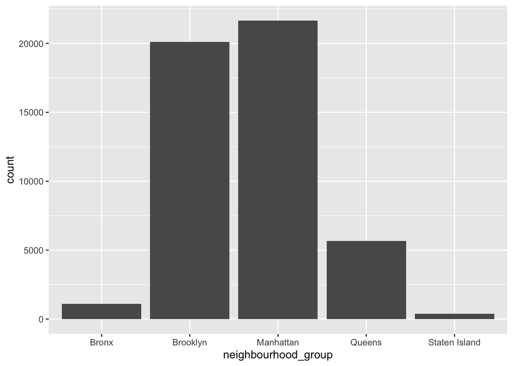

```r
# Number of airbnbs by borough type
borough_split <- ggplot(data = airbnb, aes(x = neighbourhood_group)) + geom_bar()
borough_split
```

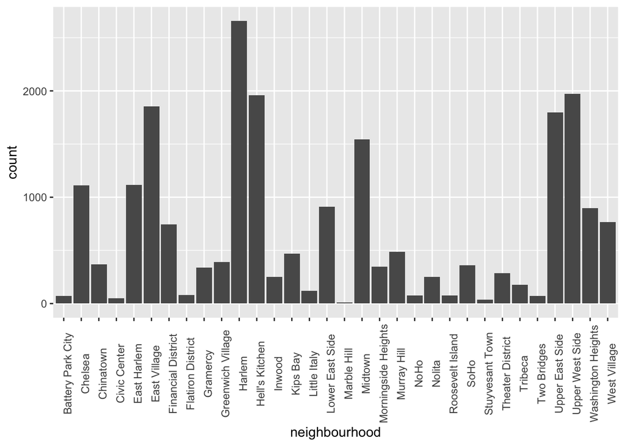

```r
# Number of airbnbs in the cities in the largest borough in NYC
airbnb %>%
  filter(neighbourhood_group == "Manhattan") %>%
  ggplot(aes(x=neighbourhood)) + geom_bar() +theme(axis.text.x = element_text(angle = 90))
```

```r
# Average price per neighborhood group
price_per_neighborhood <- round(tapply(airbnb$price,
                                      airbnb$neighbourhood_group, mean, na.rm=TRUE), 2)
price_per_neighborhood
```

```
##         Bronx      Brooklyn     Manhattan        Queens Staten Island
##         87.50        124.38        196.88         99.52        114.81
```

Manhattan is the borough with the most expensive and the largest number of airbnbs. The neighborhoods in Manhattan with the most airbnbs are Harlem, Hell’s Kitchen, East Village, the Upper West Side, and the Upper East Side.

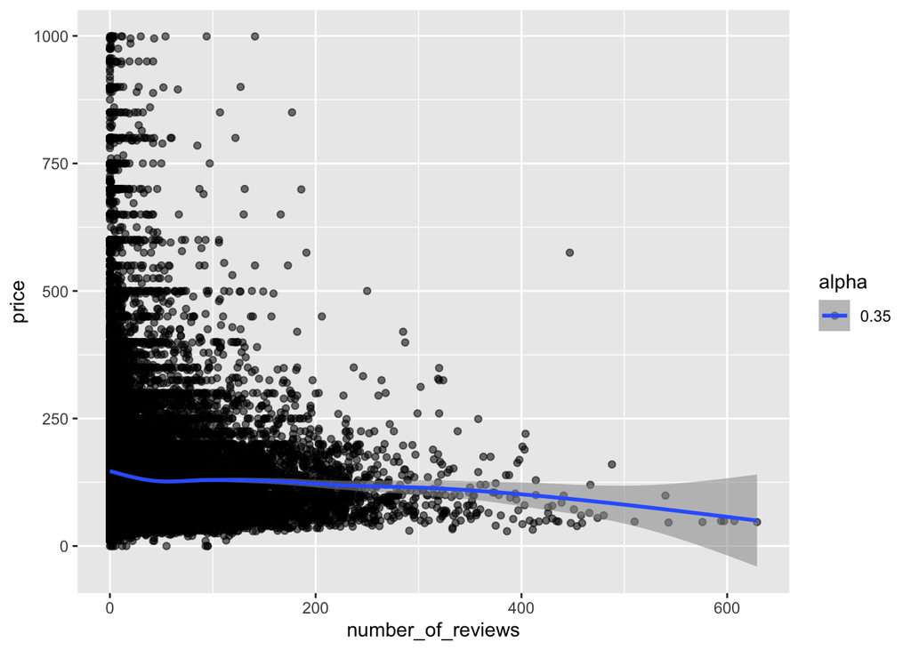

```r
# Scatterplot of reviews per airbnb less than $1000
airbnb %>%
  filter(price < 1000) %>%
  ggplot(aes(x = number_of_reviews, y = price, alpha = .35)) + geom_point() + geom_smooth()
```